# 預測報告

710661105李冠緻,710661118王聖曜

## 資料處理

丟棄fnf與seq57兩行，因兩行中變數皆無變化。

丟棄age與aid21，因存有aid19，三行為同性質之變數。

## 遺失值

-遺失值觀察

觀察出areacode變數中XX為遺失值，需處理。

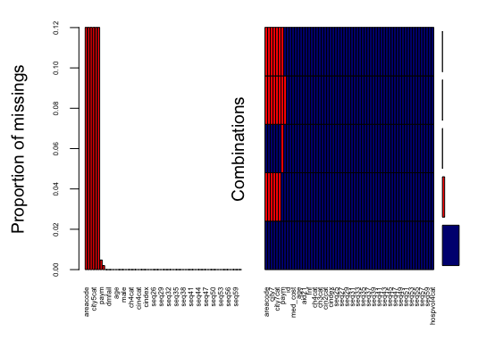

city5cat,city7,city7cat,nihno,area4cat為非隨機缺失，

city7、nihno、area4cat皆為與方位相關變數，僅留下其中area4cat來補值。

city5cat與city7cat皆與城市有關，留下city5cat進行補值。

-補值方法

cart決策樹

## 離群值

[figure not shown]

被解釋變數med_cost離群值較多，且多為向上超越，約有6000筆，預測時模型將去掉85百分位數以上之資料。

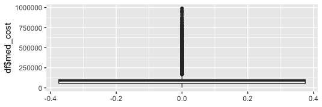

# predict med_cost

## linear regression

- train result

```
## Linear Regression
##
## 14878 samples
##    54 predictor
##
## No pre-processing
## Resampling: Cross-Validated (10 fold)
## Summary of sample sizes: 13390, 13390, 13390, 13390, 13390, 13390, ...
## Resampling results:
##
##   RMSE      Rsquared   MAE
##   16835.74  0.4501139  13740.1
##
## Tuning parameter 'intercept' was held constant at a value of TRUE
```

- test result

```
##         RMSE     Rsquared          MAE
## 1.686415e+04 4.455124e-01 1.374365e+04
```

## linear backward regression

- train result

```
## Linear Regression with Backwards Selection
##
## 14878 samples
##    54 predictor
##
## No pre-processing
## Resampling: Cross-Validated (10 fold)
## Summary of sample sizes: 13390, 13391, 13390, 13390, 13390, 13391, ...
## Resampling results across tuning parameters:
##
##   nvmax  RMSE      Rsquared   MAE
##   2      17151.73  0.4290469  14050.81
##   3      17111.45  0.4317000  14012.67
##   4      17033.79  0.4368904  13949.94
##
## RMSE was used to select the optimal model using the smallest value.
## The final value used for the model was nvmax = 4.
```

- test result

```
##         RMSE     Rsquared          MAE
## 1.719301e+04 4.237295e-01 1.404687e+04
```

## linear forward regression

- train result

```
## Linear Regression with Forward Selection
##
## 14878 samples
##    54 predictor
##
## No pre-processing
## Resampling: Cross-Validated (10 fold)
## Summary of sample sizes: 13390, 13390, 13391, 13390, 13390, 13390, ...
## Resampling results across tuning parameters:
##
##   nvmax  RMSE      Rsquared   MAE
##   2      17150.18  0.4288429  14049.03
##   3      17114.72  0.4311964  14027.51
##   4      17104.90  0.4318591  14013.28
##
## RMSE was used to select the optimal model using the smallest value.
## The final value used for the model was nvmax = 4.
```

- test result

```
##         RMSE     Rsquared          MAE
## 1.718131e+04 4.244843e-01 1.402285e+04
```

## ridge

- train result

```
## glmnet
##
## 14878 samples
##    54 predictor
##
## No pre-processing
## Resampling: Cross-Validated (10 fold)
## Summary of sample sizes: 13390, 13390, 13390, 13390, 13390, 13391, ...
## Resampling results across tuning parameters:
##
##   lambda  RMSE      Rsquared   MAE
##   0.1     16852.06  0.4499121  13880.99
##   0.2     16852.06  0.4499121  13880.99
##   0.3     16852.06  0.4499121  13880.99
##   0.4     16852.06  0.4499121  13880.99
##   0.5     16852.06  0.4499121  13880.99
##
## Tuning parameter 'alpha' was held constant at a value of 0
## RMSE was used to select the optimal model using the smallest value.
## The final values used for the model were alpha = 0 and lambda = 0.5.
```

- test result

```
##         RMSE     Rsquared          MAE
## 1.688676e+04 4.451636e-01 1.388669e+04
```

## lasso

- train result

```
## glmnet
##
## 14878 samples
##    54 predictor
##
## No pre-processing
## Resampling: Cross-Validated (10 fold)
## Summary of sample sizes: 13390, 13390, 13390, 13390, 13391, 13390, ...
## Resampling results across tuning parameters:
##
##   lambda  RMSE      Rsquared   MAE
##   0.1     16830.79  0.4499881  13737.92
##   0.2     16830.79  0.4499881  13737.92
##   0.3     16830.79  0.4499881  13737.92
##   0.4     16830.79  0.4499881  13737.92
##   0.5     16830.79  0.4499881  13737.92
##
## Tuning parameter 'alpha' was held constant at a value of 1
## RMSE was used to select the optimal model using the smallest value.
## The final values used for the model were alpha = 1 and lambda = 0.5.
```

- test result

```
##         RMSE     Rsquared          MAE
## 1.685421e+04 4.461576e-01 1.373619e+04
```

## pcr

- train result

```
## Principal Component Analysis
##
## 14878 samples
##    54 predictor
##
## No pre-processing
## Resampling: Cross-Validated (10 fold)
## Summary of sample sizes: 13390, 13391, 13391, 13390, 13390, 13390, ...
## Resampling results across tuning parameters:
##
##   ncomp  RMSE      Rsquared      MAE
##   1      22688.48  0.0004860063  20810.75
##   2      22688.04  0.0011059676  20806.47
##   3      22686.46  0.0008690303  20798.52
##
## RMSE was used to select the optimal model using the smallest value.
## The final value used for the model was ncomp = 3.
```

- test result

```
##         RMSE     Rsquared          MAE
## 2.264682e+04 1.051504e-04 2.077480e+04
```

## gam

- train result

```
## Generalized Additive Model using Splines
##
## 14878 samples
##    54 predictor
##
## No pre-processing
## Resampling: Cross-Validated (10 fold)
## Summary of sample sizes: 13390, 13391, 13390, 13390, 13390, 13390, ...
## Resampling results across tuning parameters:
##
##   select  RMSE      Rsquared   MAE
##   FALSE   16810.78  0.4519488  13712.83
##    TRUE   16809.26  0.4520478  13712.84
##
## Tuning parameter 'method' was held constant at a value of GCV.Cp
## RMSE was used to select the optimal model using the smallest value.
## The final values used for the model were select = TRUE and method = GCV.Cp.
```

- test result

```
##         RMSE     Rsquared          MAE
## 1.685572e+04 4.460614e-01 1.372146e+04
```

## select model

### compare model

```
##                      Rsquare       rmse
## linear regression     0.4450 16864.0000
## backward              0.4240 17193.0000
## forward               0.4240 17181.0000
## ridge                 0.4450 16886.0000
## lasso                 0.4460 16854.0000
## pcr                   0.0001 22646.0000
## gam                   0.4460 16855.0000
```

### best model

- 擁有最好準確率的模型為lasso，Rsquare為0.446，rmse為16854，接著我們使用它來預測答案。

# predict dmfail

## logistic regression

### train result

```
## Generalized Linear Model
##
## 17501 samples
##    55 predictor
##     2 classes: '0', '1'
##
## No pre-processing
## Resampling: Cross-Validated (10 fold)
## Summary of sample sizes: 15751, 15750, 15751, 15751, 15751, 15751, ...
## Resampling results:
##
##   Accuracy   Kappa
##   0.6907031  0.2904229
```

### confusion matrix

```
## Confusion Matrix and Statistics
##
##           Reference
## Prediction    0    1
##          0 1185  798
##          1 1553 3963
##
##                Accuracy : 0.6865
##                  95% CI : (0.6759, 0.697)
##     No Information Rate : 0.6349
##     P-Value [Acc > NIR] : < 2.2e-16
##
##                   Kappa : 0.2817
##  Mcnemar's Test P-Value : < 2.2e-16
##
##             Sensitivity : 0.8324
##             Specificity : 0.4328
##          Pos Pred Value : 0.7185
##          Neg Pred Value : 0.5976
##              Prevalence : 0.6349
##          Detection Rate : 0.5285
##    Detection Prevalence : 0.7356
##       Balanced Accuracy : 0.6326
##
##        'Positive' Class : 1
##
```

### roc

```
##
## Call:
## roc.default(response = df_test$dmfail, predictor = regreg_pred$`1`)
##
## Data: regreg_pred$`1` in 2738 controls (df_test$dmfail 0) < 4761 cases (df_test$dmfail 1).
## Area under the curve: 0.7231
```

## logistic rigid

### train result

```
## glmnet
##
## 17501 samples
##    55 predictor
##     2 classes: '0', '1'
##
## No pre-processing
## Resampling: Cross-Validated (10 fold)
## Summary of sample sizes: 15751, 15751, 15751, 15750, 15751, 15751, ...
## Resampling results across tuning parameters:
##
##   lambda  Accuracy   Kappa
##   0.1     0.6891035  0.2593830
##   0.2     0.6827605  0.2241756
##   0.3     0.6796749  0.2018565
##   0.4     0.6720755  0.1669771
##   0.5     0.6652188  0.1324917
##
## Tuning parameter 'alpha' was held constant at a value of 0
## Accuracy was used to select the optimal model using the largest value.
## The final values used for the model were alpha = 0 and lambda = 0.1.
```

### confusion matrix

```
## Confusion Matrix and Statistics
##
##           Reference
## Prediction    0    1
##          0  943  580
##          1 1795 4181
##
##                Accuracy : 0.6833
##                  95% CI : (0.6726, 0.6938)
##     No Information Rate : 0.6349
##     P-Value [Acc > NIR] : < 2.2e-16
##
##                   Kappa : 0.2458
##  Mcnemar's Test P-Value : < 2.2e-16
##
##             Sensitivity : 0.8782
##             Specificity : 0.3444
##          Pos Pred Value : 0.6996
##          Neg Pred Value : 0.6192
##              Prevalence : 0.6349
##          Detection Rate : 0.5575
##    Detection Prevalence : 0.7969
##       Balanced Accuracy : 0.6113
##
##        'Positive' Class : 1
##
```

### roc

```
##
## Call:
## roc.default(response = df_test$dmfail, predictor = rigid_pred$`1`)
##
## Data: rigid_pred$`1` in 2738 controls (df_test$dmfail 0) < 4761 cases (df_test$dmfail 1).
## Area under the curve: 0.7231
```

## logistic lasso

### train result

```
## glmnet
##
## 17501 samples
##    55 predictor
##     2 classes: '0', '1'
##
## No pre-processing
## Resampling: Cross-Validated (10 fold)
## Summary of sample sizes: 15751, 15751, 15750, 15751, 15751, 15751, ...
## Resampling results across tuning parameters:
##
##   lambda  Accuracy  Kappa
##   0.1     0.634878  0
##   0.2     0.634878  0
##   0.3     0.634878  0
##   0.4     0.634878  0
##   0.5     0.634878  0
##
## Tuning parameter 'alpha' was held constant at a value of 1
## Accuracy was used to select the optimal model using the largest value.
## The final values used for the model were alpha = 1 and lambda = 0.5.
```

### confusion matrix

```
## Confusion Matrix and Statistics
##
##           Reference
## Prediction    0    1
##          0    0    0
##          1 2738 4761
##
##                Accuracy : 0.6349
##                  95% CI : (0.6239, 0.6458)
##     No Information Rate : 0.6349
##     P-Value [Acc > NIR] : 0.5052
##
##                   Kappa : 0
##  Mcnemar's Test P-Value : <2e-16
##
##             Sensitivity : 1.0000
##             Specificity : 0.0000
##          Pos Pred Value : 0.6349
##          Neg Pred Value :    NaN
##              Prevalence : 0.6349
##          Detection Rate : 0.6349
##    Detection Prevalence : 1.0000
##       Balanced Accuracy : 0.5000
##
##        'Positive' Class : 1
##
```

### roc

```
##
## Call:
## roc.default(response = df_test$dmfail, predictor = lasso_pred$`1`)
##
## Data: lasso_pred$`1` in 2738 controls (df_test$dmfail 0) < 4761 cases (df_test$dmfail 1).
## Area under the curve: 0.5
```

## logistic GAM

### train result

```
## Generalized Additive Model using Splines
##
## 17501 samples
##    55 predictor
##     2 classes: '0', '1'
##
## No pre-processing
## Resampling: Cross-Validated (10 fold)
## Summary of sample sizes: 15751, 15751, 15751, 15751, 15751, 15750, ...
## Resampling results across tuning parameters:
##
##   select  Accuracy   Kappa
##   FALSE   0.7132730  0.3473004
##    TRUE   0.7136726  0.3481747
##
## Tuning parameter 'method' was held constant at a value of GCV.Cp
## Accuracy was used to select the optimal model using the largest value.
## The final values used for the model were select = TRUE and method = GCV.Cp.
```

### confusion matrix

```
## Confusion Matrix and Statistics
##
##           Reference
## Prediction    0    1
##          0 1332  703
##          1 1406 4058
##
##                Accuracy : 0.7188
##                  95% CI : (0.7084, 0.7289)
##     No Information Rate : 0.6349
##     P-Value [Acc > NIR] : < 2.2e-16
##
##                   Kappa : 0.3584
##  Mcnemar's Test P-Value : < 2.2e-16
##
##             Sensitivity : 0.8523
##             Specificity : 0.4865
##          Pos Pred Value : 0.7427
##          Neg Pred Value : 0.6545
##              Prevalence : 0.6349
##          Detection Rate : 0.5411
##    Detection Prevalence : 0.7286
##       Balanced Accuracy : 0.6694
##
##        'Positive' Class : 1
##
```

### roc

```
##
## Call:
## roc.default(response = df_test$dmfail, predictor = GAM_pred$`1`)
##
## Data: GAM_pred$`1` in 2738 controls (df_test$dmfail 0) < 4761 cases (df_test$dmfail 1).
## Area under the curve: 0.7588
```

## Decision Tree

### train result

```
## CART
##
## 17501 samples
##    55 predictor
##     2 classes: '0', '1'
##
## No pre-processing
## Resampling: Cross-Validated (10 fold)
## Summary of sample sizes: 15751, 15751, 15751, 15751, 15751, 15751, ...
## Resampling results across tuning parameters:
##
##   cp           Accuracy   Kappa
##   0.009859155  0.7203018  0.37752785
##   0.017801252  0.6952737  0.26408662
##   0.116118936  0.6537351  0.07846557
##
## Accuracy was used to select the optimal model using the largest value.
## The final value used for the model was cp = 0.009859155.
```

### confusion matrix

```
## Confusion Matrix and Statistics
##
##           Reference
## Prediction    0    1
##          0 1422  802
##          1 1316 3959
##
##                Accuracy : 0.7176
##                  95% CI : (0.7072, 0.7277)
##     No Information Rate : 0.6349
##     P-Value [Acc > NIR] : < 2.2e-16
##
##                   Kappa : 0.3655
##  Mcnemar's Test P-Value : < 2.2e-16
##
##             Sensitivity : 0.8315
##             Specificity : 0.5194
##          Pos Pred Value : 0.7505
##          Neg Pred Value : 0.6394
##              Prevalence : 0.6349
##          Detection Rate : 0.5279
##    Detection Prevalence : 0.7034
##       Balanced Accuracy : 0.6755
##
##        'Positive' Class : 1
##
```

### roc

```
##
## Call:
## roc.default(response = df_test$dmfail, predictor = dtree_pred$`1`)
##
## Data: dtree_pred$`1` in 2738 controls (df_test$dmfail 0) < 4761 cases (df_test$dmfail 1).
## Area under the curve: 0.7034
```

## k-Nearest Neighbor

### train result

```
## k-Nearest Neighbors
##
## 17501 samples
##    55 predictor
##     2 classes: '0', '1'
##
## No pre-processing
## Resampling: Cross-Validated (10 fold)
## Summary of sample sizes: 15751, 15750, 15751, 15751, 15751, 15751, ...
## Resampling results across tuning parameters:
##
##   k   Accuracy   Kappa
##    3  0.6563620  0.2382594
##    5  0.6677900  0.2560263
##    7  0.6761893  0.2676841
##    9  0.6822460  0.2769969
##   11  0.6813887  0.2708885
##
## Accuracy was used to select the optimal model using the largest value.
## The final value used for the model was k = 9.
```

### confusion matrix

```
## Confusion Matrix and Statistics
##
##           Reference
## Prediction    0    1
##          0 1226  876
##          1 1512 3885
##
##                Accuracy : 0.6816
##                  95% CI : (0.6709, 0.6921)
##     No Information Rate : 0.6349
##     P-Value [Acc > NIR] : < 2.2e-16
##
##                   Kappa : 0.2775
##  Mcnemar's Test P-Value : < 2.2e-16
##
##             Sensitivity : 0.8160
##             Specificity : 0.4478
##          Pos Pred Value : 0.7198
##          Neg Pred Value : 0.5833
##              Prevalence : 0.6349
##          Detection Rate : 0.5181
##    Detection Prevalence : 0.7197
##       Balanced Accuracy : 0.6319
##
##        'Positive' Class : 1
##
```

### roc

```
##
## Call:
## roc.default(response = df_test$dmfail, predictor = knn_pred$`1`)
##
## Data: knn_pred$`1` in 2738 controls (df_test$dmfail 0) < 4761 cases (df_test$dmfail 1).
## Area under the curve: 0.6989
```

## Random Forest

### train result

```
## Random Forest
##
## 17501 samples
##    55 predictor
##     2 classes: '0', '1'
##
## No pre-processing
## Resampling: Cross-Validated (10 fold)
## Summary of sample sizes: 15751, 15751, 15751, 15750, 15751, 15751, ...
## Resampling results across tuning parameters:
##
##   mtry  Accuracy   Kappa
##     2   0.6492285  0.05318935
##    55   0.7310014  0.40076182
##   109   0.7310199  0.40000417
##
## Accuracy was used to select the optimal model using the largest value.
## The final value used for the model was mtry = 109.
```

### confusion matrix

```
## Confusion Matrix and Statistics
##
##           Reference
## Prediction    0    1
##          0 2365  262
##          1  373 4499
##
##                Accuracy : 0.9153
##                  95% CI : (0.9088, 0.9215)
##     No Information Rate : 0.6349
##     P-Value [Acc > NIR] : < 2.2e-16
##
##                   Kappa : 0.8158
##  Mcnemar's Test P-Value : 1.27e-05
##
##             Sensitivity : 0.9450
##             Specificity : 0.8638
##          Pos Pred Value : 0.9234
##          Neg Pred Value : 0.9003
##              Prevalence : 0.6349
##          Detection Rate : 0.5999
##    Detection Prevalence : 0.6497
##       Balanced Accuracy : 0.9044
##
##        'Positive' Class : 1
##
```

### roc

```
##
## Call:
## roc.default(response = df_test$dmfail, predictor = rf_pred$`1`)
##
## Data: rf_pred$`1` in 2738 controls (df_test$dmfail 0) < 4761 cases (df_test$dmfail 1).
## Area under the curve: 0.9589
```

## Neural Networks

### train result

```
## Model Averaged Neural Network
##
## 17501 samples
##    55 predictor
##     2 classes: '0', '1'
##
## No pre-processing
## Resampling: Cross-Validated (10 fold)
## Summary of sample sizes: 15750, 15751, 15751, 15751, 15751, 15751, ...
## Resampling results across tuning parameters:
##
##   size  decay  Accuracy   Kappa
##   1     0e+00  0.6348780  0.0000000000
##   1     1e-04  0.6348780  0.0000000000
##   1     1e-01  0.6386473  0.0156086376
##   3     0e+00  0.6349923  0.0003972390
##   3     1e-04  0.6349923  0.0003972390
##   3     1e-01  0.6662473  0.1242404634
##   5     0e+00  0.6349923  0.0004816210
##   5     1e-04  0.6350495  0.0007645203
##   5     1e-01  0.6943600  0.2322559386
##
## Tuning parameter 'bag' was held constant at a value of FALSE
## Accuracy was used to select the optimal model using the largest value.
## The final values used for the model were size = 5, decay = 0.1 and bag
##  = FALSE.
```

### confusion matrix

```
## Confusion Matrix and Statistics
##
##           Reference
## Prediction    0    1
##          0  131   50
##          1 2607 4711
##
##                Accuracy : 0.6457
##                  95% CI : (0.6347, 0.6565)
##     No Information Rate : 0.6349
##     P-Value [Acc > NIR] : 0.02657
##
##                   Kappa : 0.0466
##  Mcnemar's Test P-Value : < 2e-16
##
##             Sensitivity : 0.98950
##             Specificity : 0.04785
##          Pos Pred Value : 0.64376
##          Neg Pred Value : 0.72376
##              Prevalence : 0.63488
##          Detection Rate : 0.62822
##    Detection Prevalence : 0.97586
##       Balanced Accuracy : 0.51867
##
##        'Positive' Class : 1
##
```

### roc

```
##
## Call:
## roc.default(response = df_test$dmfail, predictor = nnet_pred$`1`)
##
## Data: nnet_pred$`1` in 2738 controls (df_test$dmfail 0) < 4761 cases (df_test$dmfail 1).
## Area under the curve: 0.6505
```

## Bagging

### train result

```
## Bagged CART
##
## 17501 samples
##    54 predictor
##     2 classes: '0', '1'
##
## No pre-processing
## Resampling: Cross-Validated (10 fold)
## Summary of sample sizes: 15751, 15751, 15751, 15751, 15751, 15751, ...
## Resampling results:
##
##   Accuracy   Kappa
##   0.7153302  0.3694412
```

### confusion matrix

```
## Confusion Matrix and Statistics
##
##           Reference
## Prediction    0    1
##          0 2365  309
##          1  373 4452
##
##                Accuracy : 0.9091
##                  95% CI : (0.9023, 0.9155)
##     No Information Rate : 0.6349
##     P-Value [Acc > NIR] : < 2e-16
##
##                   Kappa : 0.8029
##  Mcnemar's Test P-Value : 0.01585
##
##             Sensitivity : 0.9351
##             Specificity : 0.8638
##          Pos Pred Value : 0.9227
##          Neg Pred Value : 0.8844
##              Prevalence : 0.6349
##          Detection Rate : 0.5937
##    Detection Prevalence : 0.6434
##       Balanced Accuracy : 0.8994
##
##        'Positive' Class : 1
##
```

### roc

```
##
## Call:
## roc.default(response = df_test$dmfail, predictor = bagg_pred$`1`)
##
## Data: bagg_pred$`1` in 2738 controls (df_test$dmfail 0) < 4761 cases (df_test$dmfail 1).
## Area under the curve: 0.9536
```

## select model

### compare model

[output not shown]